# Données sur Paris PC

Author

Claude Grasland

```r
library(knitr)
## Global options
options(max.print="80")
opts_chunk$set(echo=TRUE,
               cache=FALSE,
               prompt=FALSE,
               tidy=FALSE,
               comment=NA,
               message=FALSE,
               warning=FALSE,
               options(scipen=999))
opts_knit$set(width=75)

# Packages utilitaires
library(dplyr)
library(tidyr)


# Packages graphiques

#packages cartographiques
library(sf)
library(mapsf)
```

## Objectif

Dans le cadre du projet Shiny, on se propose de mettre en relation des données issues de deux bases de nature très différentes :

- le fichier individu du RP 2019
- la base JOCAS 2020

Nous souhaitons comparer la distribution des chômeurs (issue du RP) et celle des offres d’emploi (issue de la base JOCAS).

On va commencer par préparer des jeux de données utiles à l’application Shiny en réalisant des pré-traitements d’agrégation et de nettoyage

## DONNEES GEOMETRIQUES

### Acquisition du fonds de carte

Sur le site Public Open Datasoft on peut télécharger facilement les contours des communes avec leurs différents niveaux d’agrégation. On choisit ici de télécharger les communes et arrondissements métropolitains de toute l’Ile de France en 2020 pour filtrer ensuite.

```r
myURL <- "https://public.opendatasoft.com/api/explore/v2.1/catalog/datasets/georef-france-commune-arrondissement-municipal-millesime/exports/geojson?lang=fr&refine=reg_name%3A%22%C3%8Ele-de-France%22&refine=year%3A%222020%22&facet=facet(name%3D%22reg_name%22%2C%20disjunctive%3Dtrue)&timezone=Europe%2FBerlin"

map<-st_read(myURL) %>% st_as_sf()
class(map)
```

```
[1] "sf"         "data.frame"
```

```r
names(map)
```

```
 [1] "geo_point_2d"             "year"
 [3] "bv2022_name"              "com_arm_name_upper"
 [5] "com_arm_name_lower"       "com_arm_area_code"
 [7] "com_arm_type"             "com_arm_cataeu2010_code"
 [9] "com_arm_cataeu2010_name"  "com_arm_uu2010_code"
[11] "com_arm_uu2010_status"    "com_arm_au2010_code"
[13] "com_arm_cateaav2020_code" "com_arm_cateaav2020_name"
[15] "com_arm_uu2020_code"      "com_arm_uu2020_status"
[17] "com_arm_aav2020_code"     "com_arm_cv_code"
[19] "com_arm_in_ctu"           "com_arm_siren_code"
[21] "com_arm_is_mountain_area" "reg_code"
[23] "reg_name"                 "dep_code"
[25] "dep_name"                 "arrdep_code"
[27] "arrdep_name"              "ze2020_code"
[29] "ze2020_name"              "bv2022_code"
[31] "epci_code"                "epci_name"
[33] "ept_code"                 "ept_name"
[35] "com_code"                 "com_name"
[37] "com_arm_code"             "com_arm_current_code"
[39] "com_arm_name"             "ze2010_name"
[41] "ze2010_code"              "geometry"
```

### Sélection des variables et communes utiles

On ne retient que les variables utiles et on les convertit en type *character* car certaines sont des listes. On chosisit les variables *com_arm_code* et *com_arm_name* pour obtenir la division de Paris en 20 arrondissements.

```r
map <- map %>% mutate(com_code = as.character(com_arm_code),
                       com_name = as.character(com_arm_name),
                       ept_code = as.character(ept_code),
                       ept_name = as.character(ept_name),
                       dep_code = as.character(dep_code),
                       dep_name = as.character(dep_name)) %>%
                select(com_code, com_name,
                       ept_code, ept_name,
                       dep_code, dep_name) %>%
                filter(dep_code %in% c("75","92","93","94"))
```

### Recodage des établissements public territoriaux (EPT)

Les 12 territoires du Grand Paris ont actuellement des codes peu expressifs. Et on constate par ailleurs que Paris ne dispose pas de code car ce n’est pas un Etablissement Public territorial comme les onze autres.

```r
map %>% st_drop_geometry() %>%
             select(ept_code, ept_name) %>%
             unique()
```

```
       ept_code                   ept_name
1  character(0)               character(0)
2     200057966     Vallée Sud Grand Paris
3     200057875               Est Ensemble
4     200057867             Plaine Commune
6     200058006 Grand Paris Sud Est Avenir
7     200058014    Grand-Orly Seine Bièvre
9     200057974    Grand Paris Seine Ouest
11    200058790    Grand Paris - Grand Est
13    200057941    Paris-Est-Marne et Bois
16    200057990       Boucle Nord de Seine
23    200057982     Paris Ouest La Défense
29    200058097       Paris Terres d'Envol
```

On va donc leur donner un code plus simple qi est d’usage courant sous la forme de T01 … T12 que l’on trouve facilement sur Wikipedia.

```r
map$ept_name <- ifelse(map$ept_name == "character(0)" , "Paris",map$ept_name)
table(map$ept_name)
```

```
      Boucle Nord de Seine               Est Ensemble
                         6                          9
   Grand Paris - Grand Est    Grand Paris Seine Ouest
                        14                          8
Grand Paris Sud Est Avenir    Grand-Orly Seine Bièvre
                        16                         18
                     Paris     Paris Ouest La Défense
                        20                         11
      Paris Terres d'Envol    Paris-Est-Marne et Bois
                         8                         13
            Plaine Commune     Vallée Sud Grand Paris
                         9                         11
```

```r
map$ept_code <- case_when(map$ept_name=="Boucle Nord de Seine" ~ "T05",
                          map$ept_name=="Est Ensemble" ~ "T08",
                          map$ept_name=="Grand Paris - Grand Est" ~ "T09",
                          map$ept_name=="Grand Paris Seine Ouest" ~ "T03",
                          map$ept_name=="Grand Paris Sud Est Avenir" ~ "T11",
                          map$ept_name=="Grand-Orly Seine Bièvre" ~ "T12",
                          map$ept_name=="Paris" ~ "T01",
                          map$ept_name=="Paris Ouest La Défense" ~ "T04",
                          map$ept_name=="Paris Terres d'Envol" ~ "T07",
                          map$ept_name=="Paris-Est-Marne et Bois" ~ "T10",
                          map$ept_name=="Plaine Commune" ~ "T06",
                          map$ept_name=="Vallée Sud Grand Paris" ~ "T02")

table(map$ept_code)
```

```
T01 T02 T03 T04 T05 T06 T07 T08 T09 T10 T11 T12
 20  11   8  11   6   9   8   9  14  13  16  18
```

### Création et sauvegarde des fonds de carte

On sauvegarde le fonds de carte des communes puis on crée les niveaux agrégés supérieurs. On projette l’ensemble des cartes en EPSG 2154.

```r
map_com <- map %>% st_transform(2154)
#saveRDS(map_com, "data/map_com.RDS")

map_ept <- map_com %>% group_by(ept_code, ept_name, dep_code, dep_name) %>%
                      summarise()
#saveRDS(map_ept, "data/map_ept.RDS")

map_dep <- map_com %>% group_by(dep_code, dep_name) %>%
                      summarise()
#saveRDS(map_dep, "data/map_dep.RDS")
```

### Vérification des couches cartographiques

On réalise une carte superposant l’ensemble des niveaux pour s’assurer que tout a bien fonctionné à l’aide du package **mapsf**

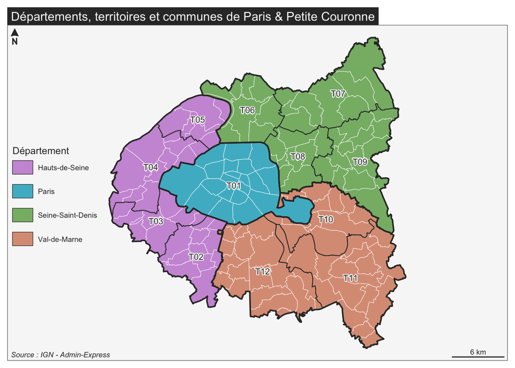

```r
mf_map(map_com, type = "typo", var="dep_name",
       lwd=0.5,
       border="white",
       leg_title = "Département",
       leg_pos = "left")
mf_map(map_ept, type = "base",
       col=NA,
       lwd=1,
       add=T)
mf_map(map_dep, type = "base",
       col=NA,
       lwd=2,
       add=T)
mf_label(map_ept, var="ept_code",halo = T)
mf_layout("Départements, territoires et communes de Paris & Petite Couronne",
          frame =T, credits = "Source : IGN - Admin-Express")
```

## DONNEES ISSUES DU RP 2019

On va créer des hypercubes croisant la localisation spatiale (à différentes échelles) avec des caractéristiques des individus ou des ménages afin de créer des hypercubes (*Cf. cours C. Grasland*). On va utiliser pour cela une fonction type (*Cf. cours de Camille Signoretto*)

### Tableau des actifs par CSP & Commune

On commence par charger les données et métadonnées :

```r
rp<-readRDS("data/Shiny_ParisPC/raw/RP/RP_final.RDS")
meta<-readRDS("data/Shiny_ParisPC/raw/RP/meta.RDS")
```

On s’intéresse à la variable CS1 dont on vérifie les attibuts :

```r
tabmod<-meta %>% filter(COD_VAR=="CS1") %>% select(COD_MOD,LIB_MOD)
tabmod
```

```
  COD_MOD                                           LIB_MOD
1       1                          Agriculteurs exploitants
2       2       Artisans, commerçants et chefs d'entreprise
3       3 Cadres et professions intellectuelles supérieures
4       4                        Professions Intermédiaires
5       5                                          Employés
6       6                                          Ouvriers
7       7                                         Retraités
8       8    Autres personnes sans activité professionnelle
```

On élimine les retraités et autres inactifs et on fusionne les agriculteurs avec les artisans et commerçants. Puis on garde les variables utiles :

```r
sel <- rp %>% mutate(com_code=substr(IRIS,1,5)) %>%
       mutate(CS1_moda=case_when(CS1 == "1" ~ "art",
                             CS1 == "2" ~ "art",
                             CS1 == "3" ~ "cad",
                             CS1 == "4" ~ "int",
                             CS1 == "5" ~ "emp",
                             CS1 == "6" ~ "ouv",
                             TRUE ~ NA)) %>%
       filter(is.na(CS1_moda)==F) %>%
       select(com_code,CS1_moda, IPONDI, SEXE)
head(sel)
```

```
  com_code CS1_moda   IPONDI SEXE
1    75112      cad 3.668459    1
2    75112      cad 3.668459    1
3    75116      cad 3.138701    2
4    75118      emp 3.451586    1
5    75118      emp 3.451586    2
6    75115      emp 3.470982    2
```

On crée une fonction adaptée qu’on pourra réutiliser :

```r
agreg_soc_geo <-function(data=data,
                    var_soc=var_soc,
                    var_geo = var_geo,
                    wgt = wgt){

  som <- data %>%
    group_by({{var_geo}}) %>%
    count({{var_soc}}, wt={{wgt}}) %>%
    mutate(n=round(n)) %>%
    pivot_wider(names_from = {{var_soc}}, values_from = n,values_fill = 0) %>%
    as.data.frame()
    som$tot <- apply(som[,-1],1,sum,na.rm=T)


  return(som)
}
```

On applique la fonction :

```r
tab_com_csp <- agreg_soc_geo(data=sel,
                        var_soc = CS1_moda,
                        var_geo=com_code,
                        wgt=IPONDI)
head(tab_com_csp)
```

```
  com_code  art   cad  emp  int  ouv   tot
1    75101  867  4540 1491 1836  474  9208
2    75102 1124  7495 2088 2938  755 14400
3    75103 1684 10884 3051 4689  835 21143
4    75104 1308  8399 2787 3747  677 16918
5    75105 1959 16722 4011 5922 1112 29726
6    75106 1857 10817 2648 3691  712 19725
```

On sauvegarde le tableau :

```r
#saveRDS(tab_com_csp,'data/Shiny_ParisPC/data/tab_com_csp.RDS')
```

### Tableau des chômeurs par CSP et Commune

On souhaite maintenant construire un tableau localisant les chômeurs par commune et CSP. Il suffit de reprendre nos programmes précédents en sélecionnant les chômeurs dans TACT

```r
sel<-rp %>% filter(TACT==12) %>%
       mutate(com_code=substr(IRIS,1,5)) %>%
       mutate(CS1_moda=case_when(CS1 == "1" ~ "art",
                             CS1 == "2" ~ "art",
                             CS1 == "3" ~ "cad",
                             CS1 == "4" ~ "int",
                             CS1 == "5" ~ "emp",
                             CS1 == "6" ~ "ouv",
                             TRUE ~ NA)) %>%
       filter(is.na(CS1_moda)==F)

tab_com_csp_chom<- agreg_soc_geo( data=sel,
                             var_soc = CS1_moda,
                             var_geo=com_code,
                             wgt=IPONDI)

head(tab_com_csp_chom)
```

```
  com_code art cad emp int ouv  tot
1    75101  36 246 220 229 111  842
2    75102  35 440 327 372 108 1282
3    75103  63 724 434 515 168 1904
4    75104  52 606 443 468 122 1691
5    75105  80 869 516 683 199 2347
6    75106  48 647 297 579  81 1652
```

```r
saveRDS(tab_com_csp_chom, "data/tab_com_csp_chom.RDS")
```

## DONNEES ISSUES DE JOCAS 2020

Nous allons maintenant essayer de construire une base de données des offres d’emploi par type de métier au niveau des communes. Plusieurs difficultés vont se présenter, les deux principales étant :

1. que l’on ne dispose pas des codes communaux mais uniquement des codes postaux
2. que les offres d’emplois ne sont pas classées par CSP mais par code ROME

### Chargement de la base

```r
base <- readRDS("data/Shiny_ParisPC/raw/jocas/jocas_ParisPC.RDS")

sel <- base %>%   mutate(zip_code = as.character(location_zipcode),
                         dep_code = as.character(location_departement),
                         rom_code = as.character(job_ROME_code)) %>%
                  select(zip_code,dep_code,rom_code)
```

### Transformation des codes postaux en code communaux

On charge une table de correspondance trouvée sur Public Open Datasoft

```r
zip_to_com <- readRDS("data/Shiny_ParisPC/raw/jocas/zip_code_to_com_code.RDS")
head(zip_to_com)
```

```
  zip_code       zip_name    zip_type com_code
1    75029 PARIS CEDEX 01  Code CEDEX    75101
2    75026 PARIS CEDEX 01  Code CEDEX    75101
3    75058 PARIS CEDEX 01  Code CEDEX    75101
4    75054 PARIS CEDEX 01  Code CEDEX    75101
5    75056 PARIS CEDEX 01  Code CEDEX    75101
6    75001       PARIS 01 Code Postal    75101
```

Puis on effectue la jointure et on examine combien d’offres d’emploi ont pu être localisées par commune :

```r
sel <-sel %>% left_join(zip_to_com)
table(is.na(sel$com_code))
```

```
 FALSE   TRUE
329816  90707
```

On procède ensuite à une cartographie rapide des offres d’emploi par commune :

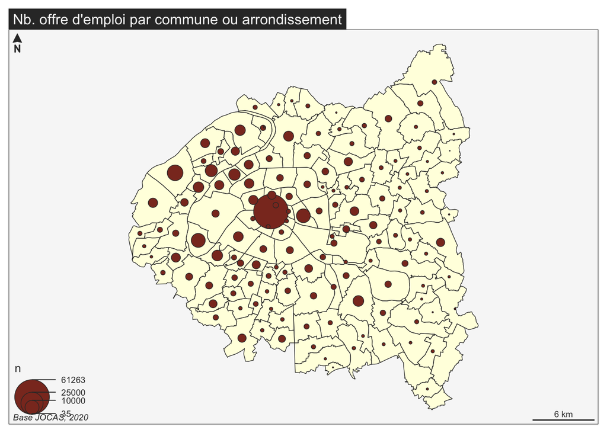

```r
tab_job <- sel %>% group_by(com_code) %>% count()
map_com <- readRDS("data/Shiny_ParisPC/data/map_com.RDS")
map_com <-map_com %>% left_join(tab_job)

mf_map(map_com, type="base", col="lightyellow")
mf_map(map_com, type="prop", var="n", inches=0.2)
mf_layout("Nb. offre d'emploi par commune ou arrondissement",
          frame = T,
          credits = "Base JOCAS, 2020")
```

La base semble correcte à un détail près : il y a visiblement trop d’offres d’emploi localisées dans le premier arrondissement de Paris ! On s’en rend compte en triant les offres d’empmloi par ordre décroissant de commune :

```r
map_com %>% st_drop_geometry() %>% arrange(-n) %>% head()
```

```
  com_code                 com_name ept_code                ept_name dep_code
1    75101 Paris 1er Arrondissement      T01                   Paris       75
2    92050                 Nanterre      T04  Paris Ouest La Défense       92
3    92012     Boulogne-Billancourt      T03 Grand Paris Seine Ouest       92
4    75111 Paris 11e Arrondissement      T01                   Paris       75
5    92026               Courbevoie      T04  Paris Ouest La Défense       92
6    92044         Levallois-Perret      T04  Paris Ouest La Défense       92
        dep_name     n
1          Paris 61263
2 Hauts-de-Seine 12522
3 Hauts-de-Seine  9956
4          Paris  9778
5 Hauts-de-Seine  7515
6 Hauts-de-Seine  6761
```

Il s’agit donc d’offres d’emploi qui concernent Paris dans son ensemble et auxquelles on a affecté par défaut le code postal ‘75001’. On va donc affecter la valeur NA à cet arrondissement pour éviter les erreurs et on recalcule la distributoion des valeurs manquantes.

```r
sel$com_code<-ifelse(sel$zip_code=="75001", NA, sel$com_code)
table(is.na(sel$com_code))
```

```
 FALSE   TRUE
268553 151970
```

### Codification des offres d’emploi en 14 catégories

On importe le code ROME et on choisit de regrouper en 14 grands domaines :

```r
code_rome <- readRDS("data/Shiny_ParisPC/raw/jocas/code_rome.RDS")

job <- code_rome %>% mutate(job_code = as.character(big_dom),
                               job_name = as.character(big_dom_name)) %>%
                        select(job_code, job_name) %>%
                        unique() %>%
                        arrange(job_code) %>%
                        as.data.frame()
job
```

```
   job_code
1         A
2         B
3         C
4         D
5         E
6         F
7         G
8         H
9         I
10        J
11        K
12        L
13        M
14        N
                                                                     job_name
1  Agriculture et Pêche, Espaces naturels et Espaces verts, Soins aux animaux
2                                          Arts et Façonnage d'ouvrages d'art
3                                               Banque, Assurance, Immobilier
4                                      Commerce, Vente et Grande distribution
5                                          Communication, Média et Multimédia
6                                   Construction, Bâtiment et Travaux publics
7                     Hôtellerie-Restauration, Tourisme, Loisirs et Animation
8                                                                   Industrie
9                                                 Installation et Maintenance
10                                                                      Santé
11                                Services à la personne et à la collectivité
12                                                                  Spectacle
13                                                     Support à l'entreprise
14                                                    Transport et Logistique
```

On réalise une jointure avec la base JOCAS et on dénombre les effectifs par grands domaines

```r
sel <- sel %>% mutate(job_code = substr(rom_code,1,1)) %>%
  inner_join(job)

tab_job <- sel %>% group_by(job_code, job_name) %>% count() %>% arrange(-n)
tab_job
```

```
# A tibble: 14 × 3
# Groups:   job_code, job_name [14]
   job_code job_name                                                           n
   <chr>    <chr>                                                          <int>
 1 M        Support à l'entreprise                                        126195
 2 K        Services à la personne et à la collectivité                    92964
 3 D        Commerce, Vente et Grande distribution                         43916
 4 J        Santé                                                          39801
 5 C        Banque, Assurance, Immobilier                                  23882
 6 H        Industrie                                                      22847
 7 F        Construction, Bâtiment et Travaux publics                      21503
 8 I        Installation et Maintenance                                    20395
 9 N        Transport et Logistique                                        12042
10 G        Hôtellerie-Restauration, Tourisme, Loisirs et Animation        10207
11 E        Communication, Média et Multimédia                              4571
12 A        Agriculture et Pêche, Espaces naturels et Espaces verts, Soi…   1462
13 L        Spectacle                                                        438
14 B        Arts et Façonnage d'ouvrages d'art                               266
```

### Agrégation des offres d’emploi par commune

On agrège les offres d’emploi par commune en retirant celles qui ne sont pas localisées à cette échelle ou qui n’ont pas de code rome. Pour cela on reprend notre fonction d’agrégation.

```r
sel_com <- sel %>% filter(is.na(com_code)==F) %>%
                      mutate(poids=1)


tab_com_job <-agreg_soc_geo(data=sel_com, var_soc = job_code, var_geo=com_code, wgt=poids)
#saveRDS(tab_com_job,"data/tab_com_job.RDS")
```

### Agrégation des offres d’emploi par département

On réalise un second tableau des offres d’emploi par département en conservant l’ensemble des offres d’emploi c’est-à-dire en incluant celles pour lesquelles on avait juste le département.

```r
sel_dep <- sel %>% mutate(poids=1)


tab_dep_job <-agreg_soc_geo(data=sel_dep, var_soc = job_code, var_geo=dep_code, wgt=poids)
#saveRDS(tab_com_job,"data/tab_dep_job.RDS")
```